# Importaciones

### Serie de tiempo de la gasolina Super

En este caso utilizaremos la construccion de modelos ARIMA el cual consta de 4 pasos, 1. Indentificacion 2. Estimacion 3. Validacion 4. Prediccion

#### Identificacion

```r
#Series de tiempo


library(forecast)
library(tseries)
library(fUnitRoots)
library(ggfortify)

importacion <- read_excel("importacion.xlsx")

regular<-importacion[c('Fecha','Gasolina regular')]
diesel<-importacion[c('Fecha','Diesel alto azufre')]
super<-importacion[c('Fecha','Gasolina superior')]

super_ts <- ts( super$`Gasolina superior`, start = c(2001,1),frequency = 12)

#Inicio de la serie de tiempo
start(super_ts)
```

```
## [1] 2001    1
```

```r
#Final de la serie de tiempo
end(super_ts)
```

```
## [1] 2022    5
```

```r
#Frecuencia de la serie
frequency(super_ts)
```

```
## [1] 12
```

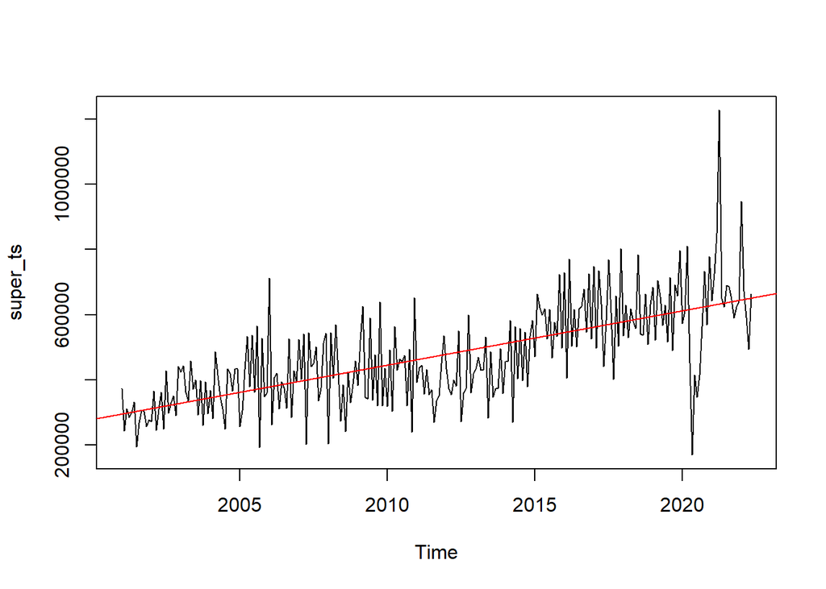

```r
#Grafica generada
plot(super_ts)
abline(reg=lm(super_ts~time(super_ts)), col=c("red"))
```

Como se observa anteriormente, la grafica nos demuestra el comportamiento de la importacion de la gasolina superior desde 2001 hasta mayo de 2022, donde se observa que en el año 2020 la importacion de gasolina Super tuvo una ‘crisis’ esto puede considerarse por la pandemia del COVID-19. Y que despues de la pandemia tuvo un pico considerable.

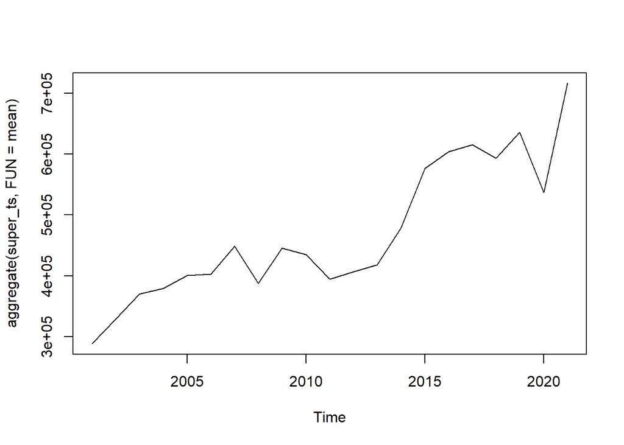

```r
plot(aggregate(super_ts,FUN=mean))
```

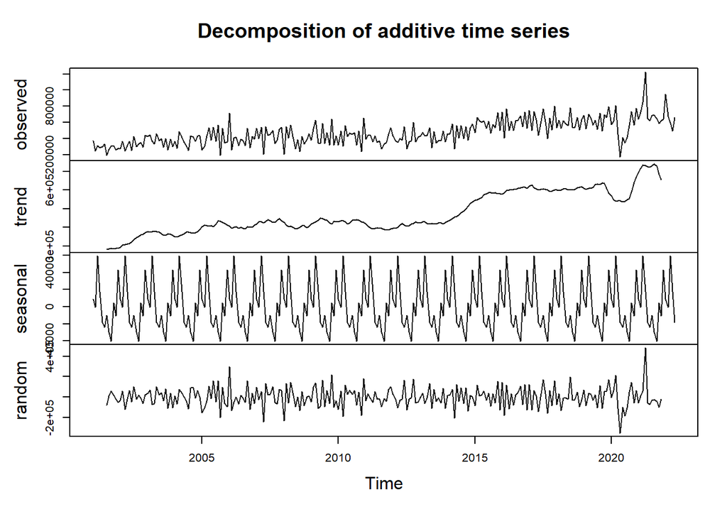

```r
dec.Super<-decompose(super_ts)
plot(dec.Super)
```

Podemos observar una serie con tendencia a aumentar, que no es estacionaria en varianza, y además tiene estacionalidad.

#### Estimacion

Cómo no es estacionaria en varianza le haremos una transformación logaritmica para hacerla constante en varianza.Lo haremos con la serie de entrenamiento que es la que nos ayudará a predecir

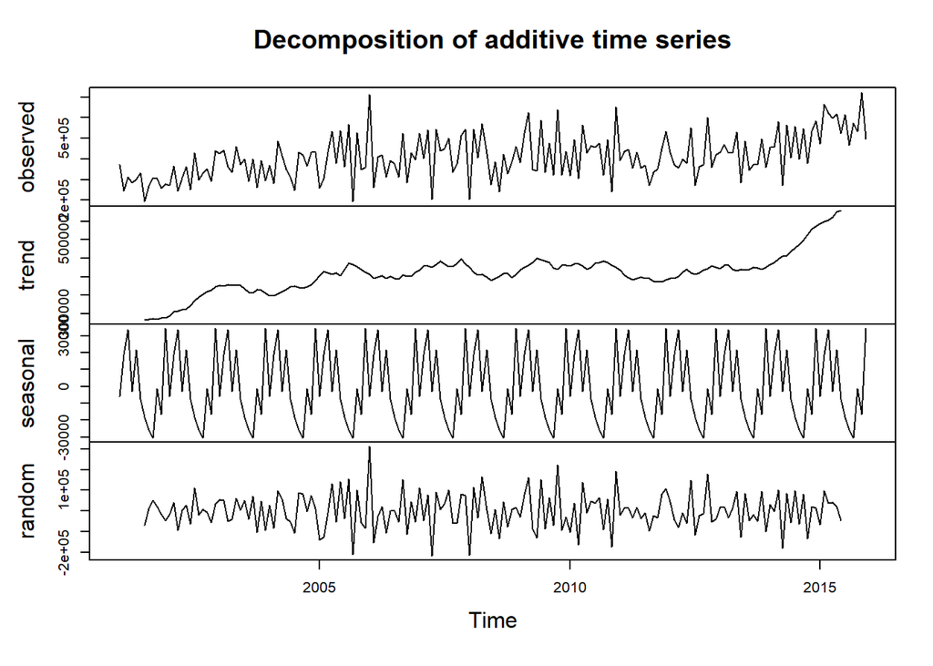

```r
train <- head(super_ts, round(length(super_ts) * 0.7))
h <- length(super_ts) - length(train)
test <- tail(super_ts, h)

#Aplicaremos una transformación logarítmica
logSuper <- log(train)
plot(decompose(train))
```

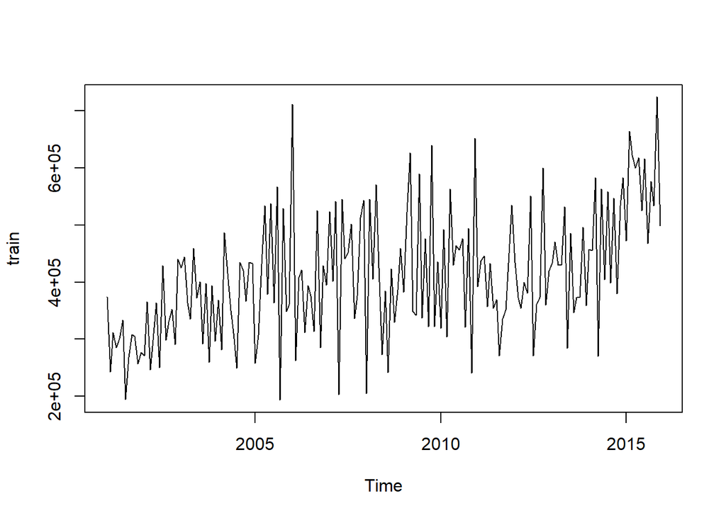

```r
#Ver el gráfico de la serie
plot(train)
```

```r
#Para saber si hay raíces unitarias
adfTest(train)
```

```
##
## Title:
##  Augmented Dickey-Fuller Test
##
## Test Results:
##   PARAMETER:
##     Lag Order: 1
##   STATISTIC:
##     Dickey-Fuller: -0.594
##   P VALUE:
##     0.4255
##
## Description:
##  Mon Aug 08 23:40:01 2022 by user: xavih
```

```r
unitrootTest(train)
```

```
##
## Title:
##  Augmented Dickey-Fuller Test
##
## Test Results:
##   PARAMETER:
##     Lag Order: 1
##   STATISTIC:
##     DF: -0.594
##   P VALUE:
##     t: 0.4589
##     n: 0.5487
##
## Description:
##  Mon Aug 08 23:40:01 2022 by user: xavih
```

Como se observa en varias pruebas el valor de P es mayor a 0.05 por lo que no se puede rechazar la hipotis nula de ausencia de raices. Esto significa que no es estacionaria en media. Ahora veamos con diferenciacion.

```r
adfTest(diff(train))
```

```
##
## Title:
##  Augmented Dickey-Fuller Test
##
## Test Results:
##   PARAMETER:
##     Lag Order: 1
##   STATISTIC:
##     Dickey-Fuller: -17.2135
##   P VALUE:
##     0.01
##
## Description:
##  Mon Aug 08 23:40:01 2022 by user: xavih
```

```r
unitrootTest(diff(train))
```

```
##
## Title:
##  Augmented Dickey-Fuller Test
##
## Test Results:
##   PARAMETER:
##     Lag Order: 1
##   STATISTIC:
##     DF: -17.2135
##   P VALUE:
##     t: < 2.2e-16
##     n: 0.003256
##
## Description:
##  Mon Aug 08 23:40:01 2022 by user: xavih
```

Como se puede ver el valor de p ahora sí está por debajo de 0.05 por lo que se puede descartar la hipótesis nula de que existan raices unitarias. Es necesaria solo una diferenciación. Es decir d = 1. Trataremos de identificar los parámetros p y q usando los gráficos de autocorrelación y autocorrelación parcial.

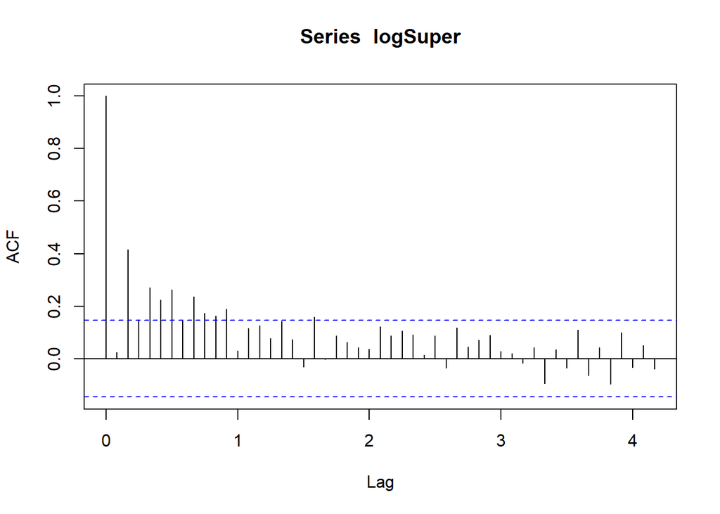

```r
#Gráfico de autocorrelación
acf(logSuper,50)
```

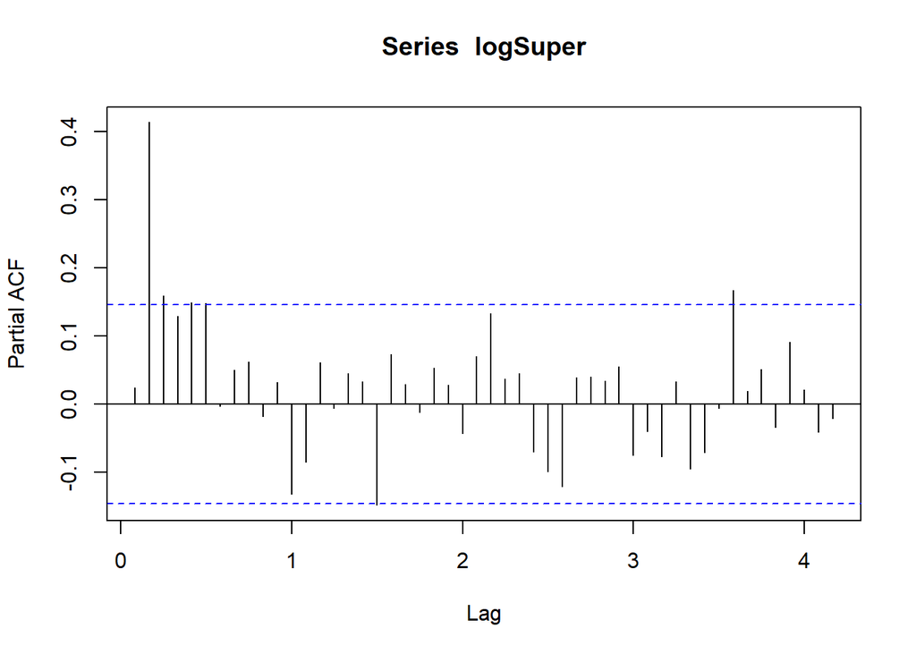

```r
pacf(logSuper,50)
```

Podemos ver que se anula después de dos retardos por lo que podíamos plantear que el coeficiente p = 1.

Podríamos elaborar un modelo con los siguientes parámetros:

p=1. q=1. d=1. Es decir ARIMA(1,1,1).

Veamos si hay estacionalidad en la serie. Si volvemos a ver la descomposición de la serie en su componente estacional.

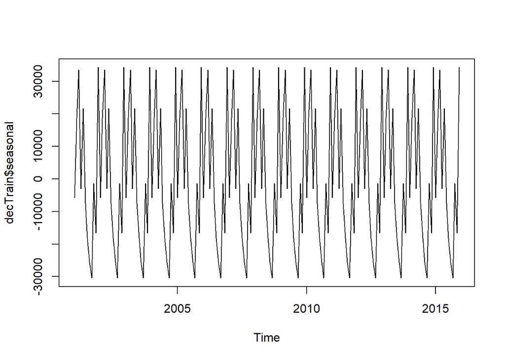

```r
decTrain <- decompose(train)
plot(decTrain$seasonal)
```

Al parecer sí existe estacionalidad en la serie. Para tener una idea de los parámetros estacionales veremos las funciones de autocorrelación y autocorrelación parcial con 36 resagos para ver en que momentos son los picos estacionales. Se usará la serie estacionarizada.

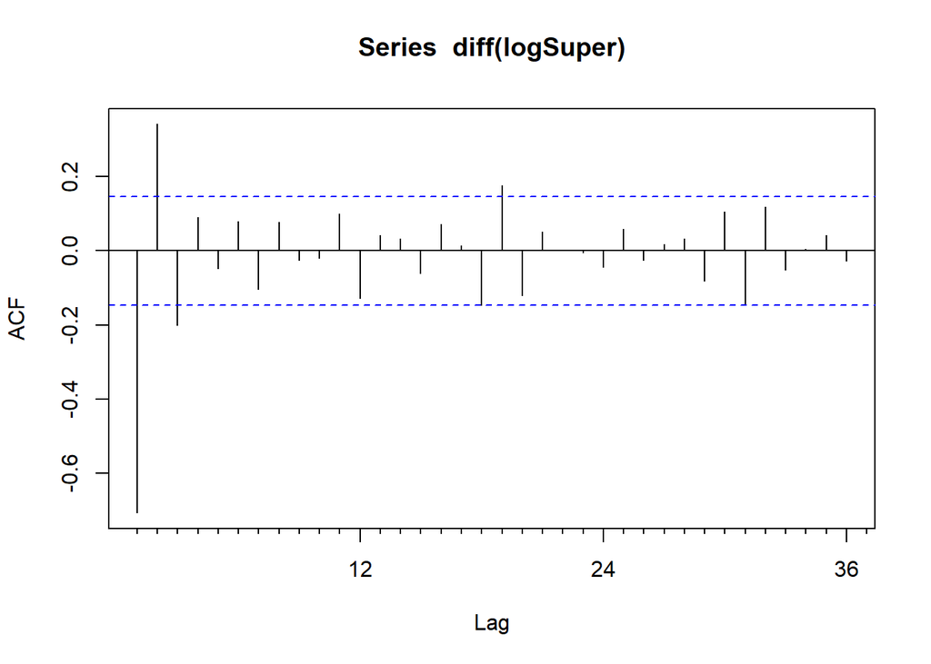

```r
Acf(diff(logSuper),36)
```

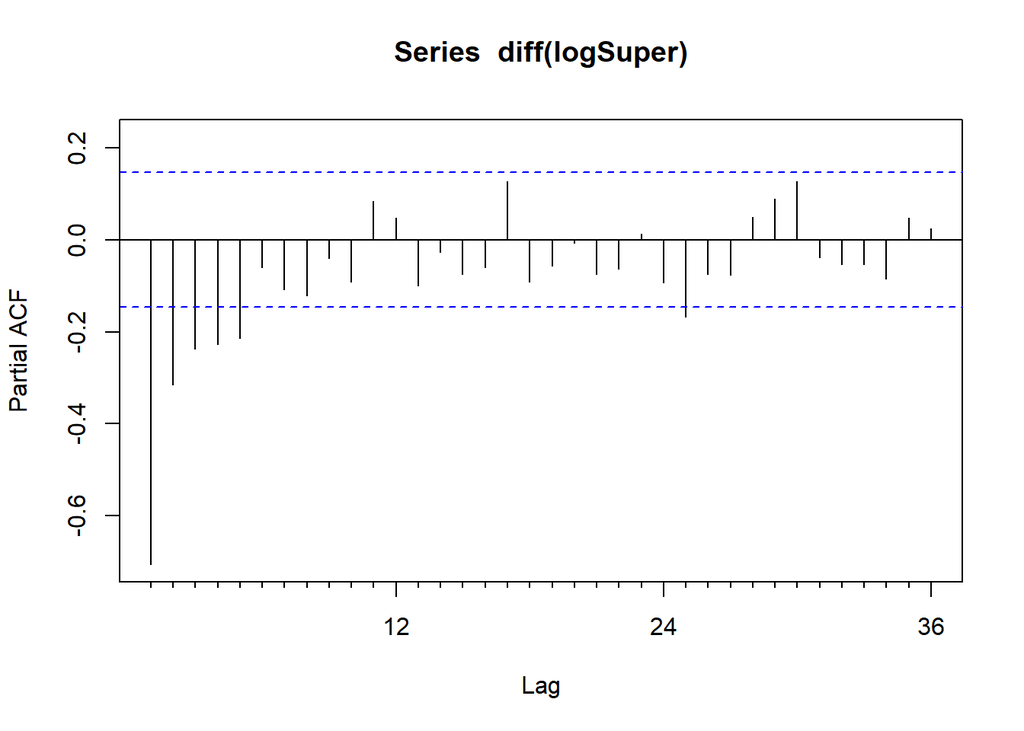

```r
Pacf(diff(logSuper),36)
```

```r
fitArima <- arima(logSuper,order=c(1,1,1),seasonal = c(1,1,0))
fitAutoArima <- auto.arima(train)
```

#### Significacion de los coeficientes

```r
library(lmtest)

coeftest(fitArima)
```

```
##
## z test of coefficients:
##
##       Estimate Std. Error  z value  Pr(>|z|)
## ar1  -0.373433   0.075145  -4.9695 6.714e-07 ***
## ma1  -0.901776   0.036575 -24.6556 < 2.2e-16 ***
## sar1 -0.550226   0.062736  -8.7705 < 2.2e-16 ***
## ---
## Signif. codes:  0 '***' 0.001 '**' 0.01 '*' 0.05 '.' 0.1 ' ' 1
```

Cómo se puede obserevar todos los coeficientes son significativos. Veamos ahora el modelo generado de forma automática por R

```r
coeftest(fitAutoArima)
```

```
##
## z test of coefficients:
##
##          Estimate  Std. Error z value  Pr(>|z|)
## ar1     -0.658389    0.141670 -4.6474 3.362e-06 ***
## ma1     -0.530149    0.174573 -3.0368  0.002391 **
## ma2     -0.279659    0.164587 -1.6992  0.089291 .
## sma1    -0.144198    0.078535 -1.8361  0.066341 .
## drift 1508.145722  691.451345  2.1811  0.029174 *
## ---
## Signif. codes:  0 '***' 0.001 '**' 0.01 '*' 0.05 '.' 0.1 ' ' 1
```

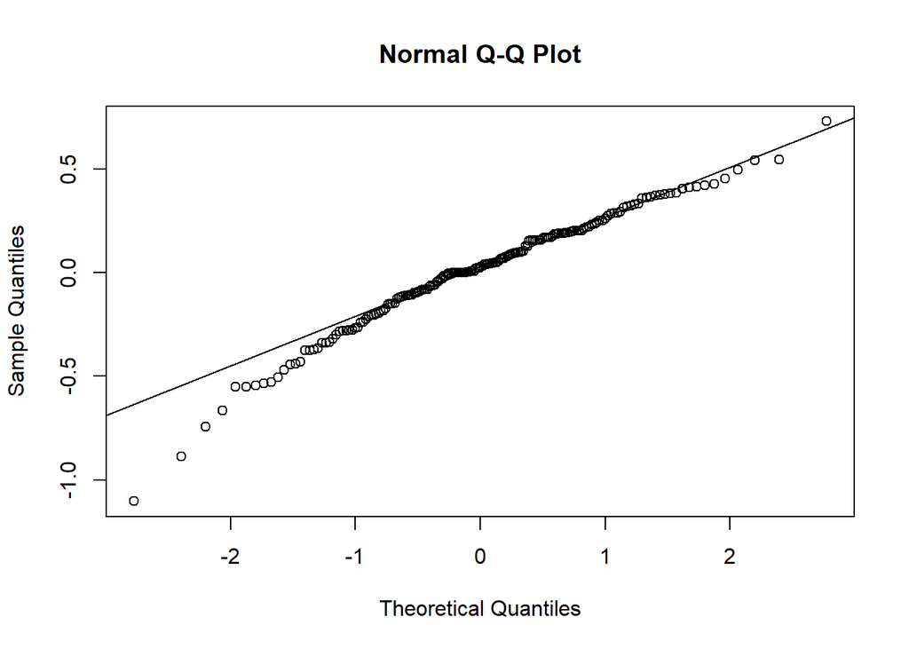

```r
qqnorm(fitArima$residuals)
qqline(fitArima$residuals)
```

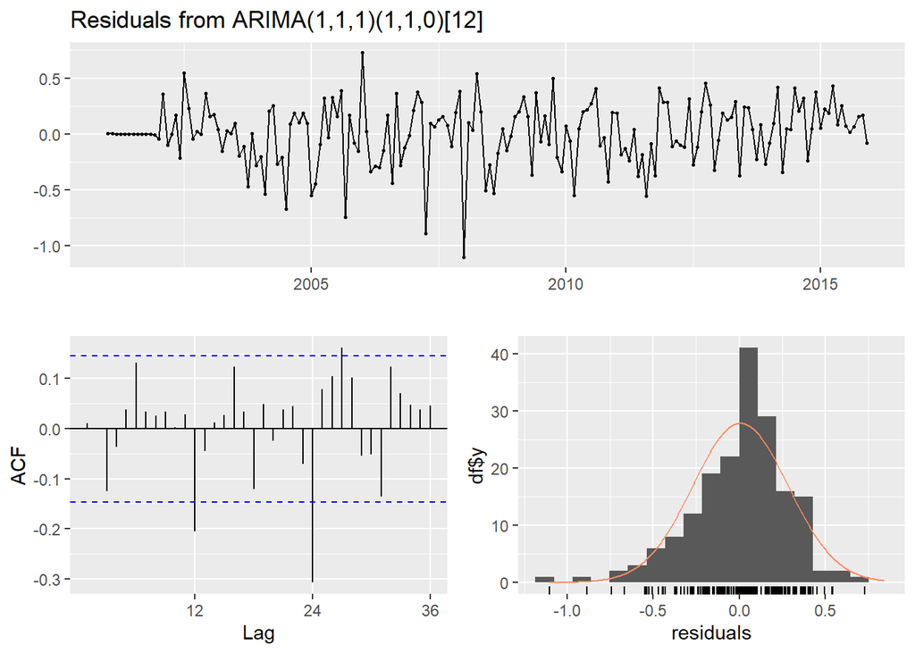

```
##
##  Ljung-Box test
##
## data:  Residuals from ARIMA(1,1,1)(1,1,0)[12]
## Q* = 44.792, df = 21, p-value = 0.001844
##
## Model df: 3.   Total lags used: 24
```

```r
checkresiduals(fitArima)
```

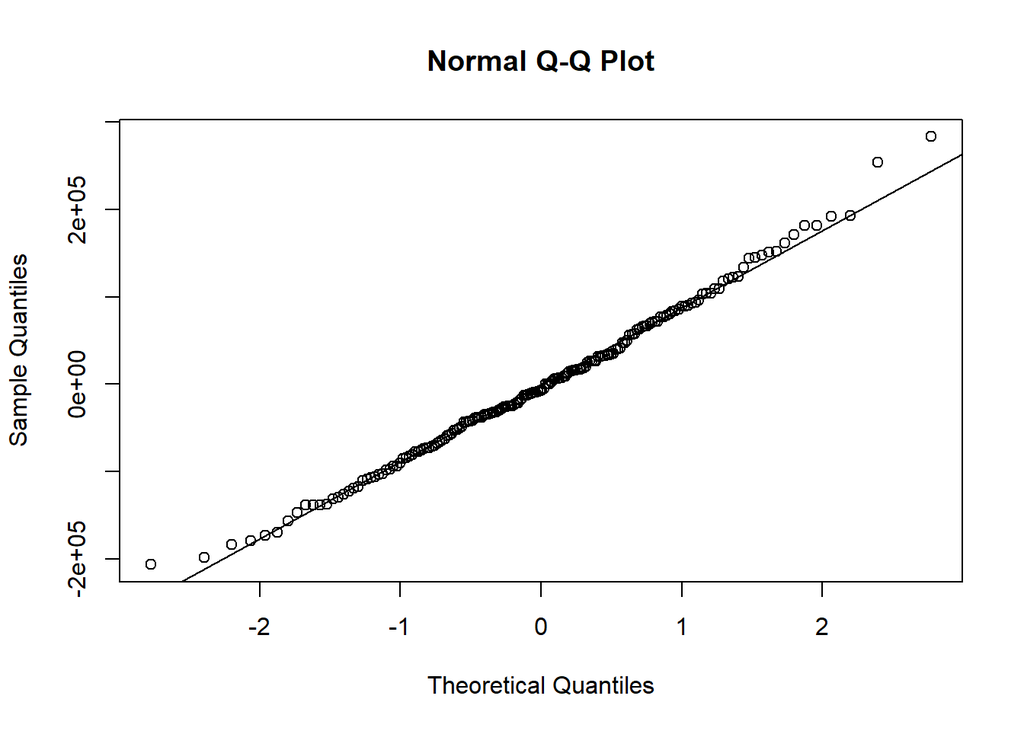

```r
qqnorm(fitAutoArima$residuals)
qqline(fitAutoArima$residuals)
```

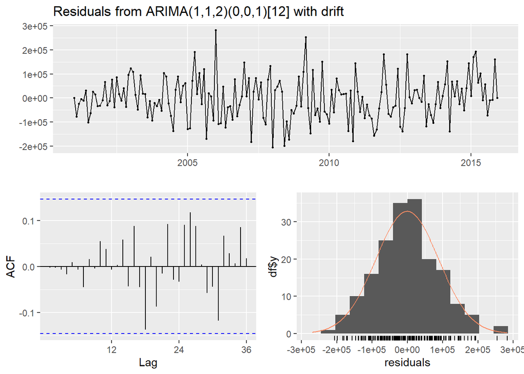

```
##
##  Ljung-Box test
##
## data:  Residuals from ARIMA(1,1,2)(0,0,1)[12] with drift
## Q* = 12.078, df = 20, p-value = 0.9134
##
## Model df: 4.   Total lags used: 24
```

```r
checkresiduals(fitAutoArima)
```

#### Prediccion

```r
# Hacer el modelo

auto.arima(super_ts)
```

```
## Series: super_ts
## ARIMA(2,1,1) with drift
##
## Coefficients:
##           ar1     ar2      ma1      drift
##       -0.0688  0.2359  -0.9503  1441.0479
## s.e.   0.0695  0.0692   0.0294   444.5508
##
## sigma^2 = 1.227e+10:  log likelihood = -3335.83
## AIC=6681.67   AICc=6681.91   BIC=6699.39
```

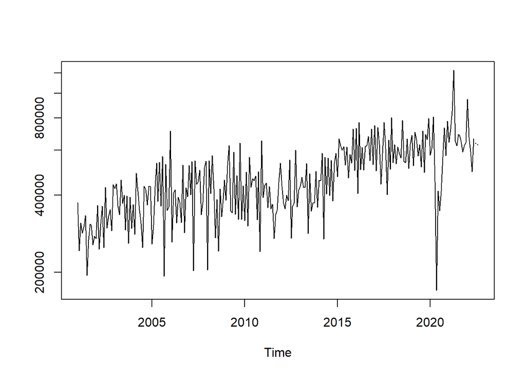

```r
fit <- arima(log(super_ts), c(0, 1, 1),seasonal = list(order = c(0, 1, 1), period = 12))
pred <- predict(fit, n.ahead = 3)
ts.plot(super_ts,2.718^pred$pred, log = "y", lty = c(1,3))
```

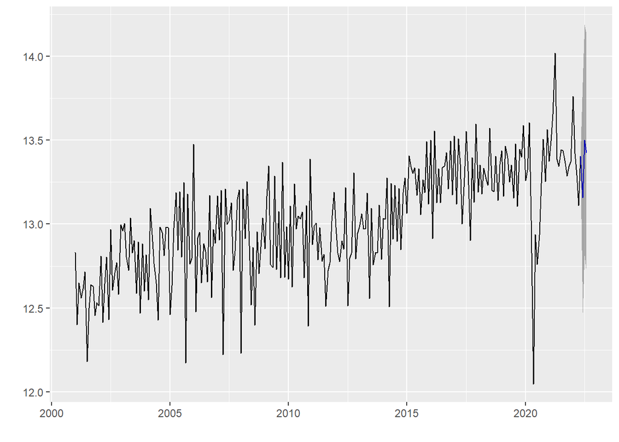

```r
fit2 <- arima(log(super_ts), c(2, 1, 1),seasonal = list(order = c(0, 1, 0), period = 12))

forecastAP <- forecast(fit2, level = c(95), h = 3)
autoplot(forecastAP)
```

```r
super_ts2018 <- ts( super$`Gasolina superior`, start = c(2001,1), end=c(2020,12) ,frequency = 12)

auto.arima(super_ts2018)
```

```
## Series: super_ts2018
## ARIMA(2,1,1) with drift
##
## Coefficients:
##           ar1     ar2      ma1      drift
##       -0.1853  0.2048  -0.9136  1235.0208
## s.e.   0.0750  0.0737   0.0332   607.0883
##
## sigma^2 = 1.052e+10:  log likelihood = -3095.72
## AIC=6201.44   AICc=6201.7   BIC=6218.82
```

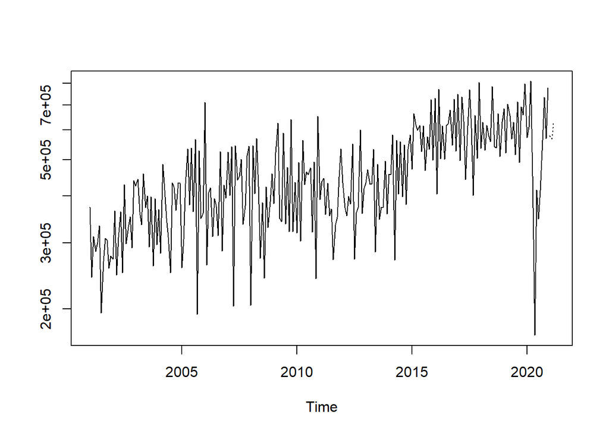

```r
fit <- arima(log(super_ts2018), c(0, 1, 1),seasonal = list(order = c(0, 1, 1), period = 12))
pred <- predict(fit, n.ahead = 3)
ts.plot(super_ts2018,2.718^pred$pred, log = "y", lty = c(1,3))
```

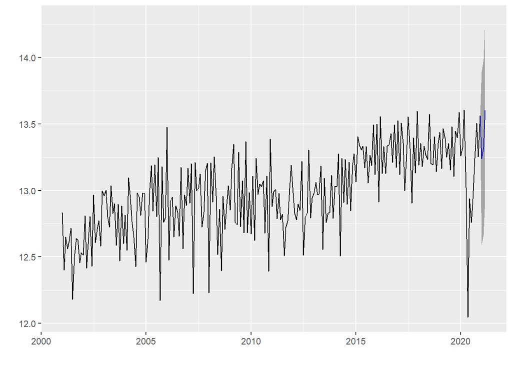

```r
fit2 <- arima(log(super_ts2018), c(2, 1, 1),seasonal = list(order = c(0, 1, 0), period = 12))

forecastAP <- forecast(fit2, level = c(95), h = 3)
autoplot(forecastAP)
```

Como se observa con las graficas anteriores, si se realizo una buena prediccion, ya que es muy similar a las graficas anteriormente generadas.

#### Prohet

```r
#install.packages('prophet')
library(prophet)
library(zoo)
df<-data.frame(ds=as.Date(as.yearmon(time(train))),y=as.matrix(train) )
testdf<-data.frame(ds=as.Date(as.yearmon(time(test))),y=as.matrix(test) )
head(df)
```

```
##           ds        y
## 1 2001-01-01 373964.0
## 2 2001-02-01 243091.1
## 3 2001-03-01 312084.4
## 4 2001-04-01 285054.9
## 5 2001-05-01 300913.7
## 6 2001-06-01 333217.2
```

```r
fitProphet<-prophet(df,yearly.seasonality = T,weekly.seasonality = T)
```

```
## Disabling daily seasonality. Run prophet with daily.seasonality=TRUE to override this.
```

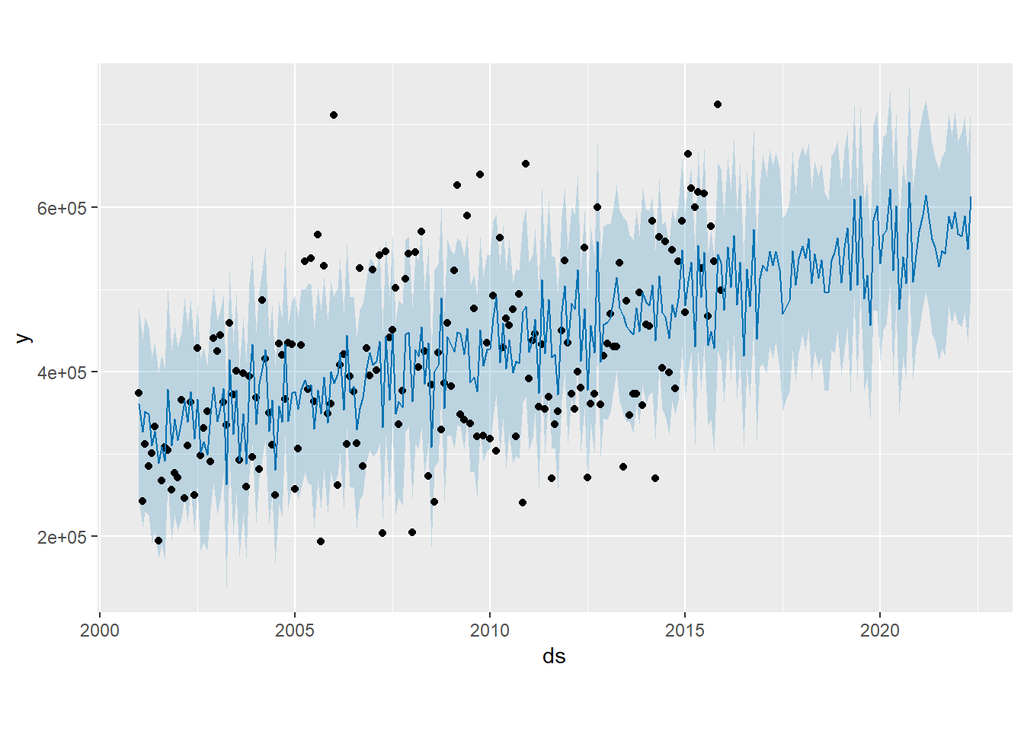

```r
future <- make_future_dataframe(fitProphet,periods = h,freq = "month", include_history = T)
p <- predict(fitProphet,future)
p<-p[,c("ds","yhat","yhat_lower","yhat_upper")]
plot(fitProphet,p)
```

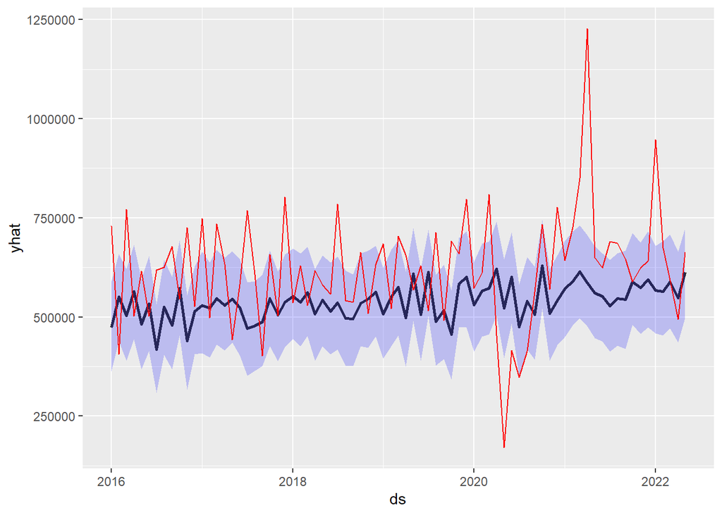

```r
pred<-tail(p,h)
pred$y<-testdf$y


ggplot(pred, aes(x=ds, y=yhat)) +
   geom_line(size=1, alpha=0.8) +
   geom_ribbon(aes(ymin=yhat_lower, ymax=yhat_upper), fill="blue", alpha=0.2) +
   geom_line(data=pred, aes(x=ds, y=y),color="red")
```

### Serie de tiempo de la gasolina Diesel

En este caso utilizaremos la construccion de modelos ARIMA el cual consta de 4 pasos, 1. Indentificacion 2. Estimacion 3. Validacion 4. Prediccion

#### Identificacion

```r
#Series de tiempo


library(forecast)
library(tseries)
library(fUnitRoots)
library(ggfortify)

importacion <- read_excel("importacion.xlsx")

regular<-importacion[c('Fecha','Gasolina regular')]
diesel<-importacion[c('Fecha','Diesel alto azufre')]
super<-importacion[c('Fecha','Gasolina superior')]

diesel_ts <- ts( diesel$`Diesel alto azufre`, start = c(2001,1),frequency = 12)

#Inicio de la serie de tiempo
start(diesel_ts)
```

```
## [1] 2001    1
```

```r
#Final de la serie de tiempo
end(diesel_ts)
```

```
## [1] 2022    5
```

```r
#Frecuencia de la serie
frequency(diesel_ts)
```

```
## [1] 12
```

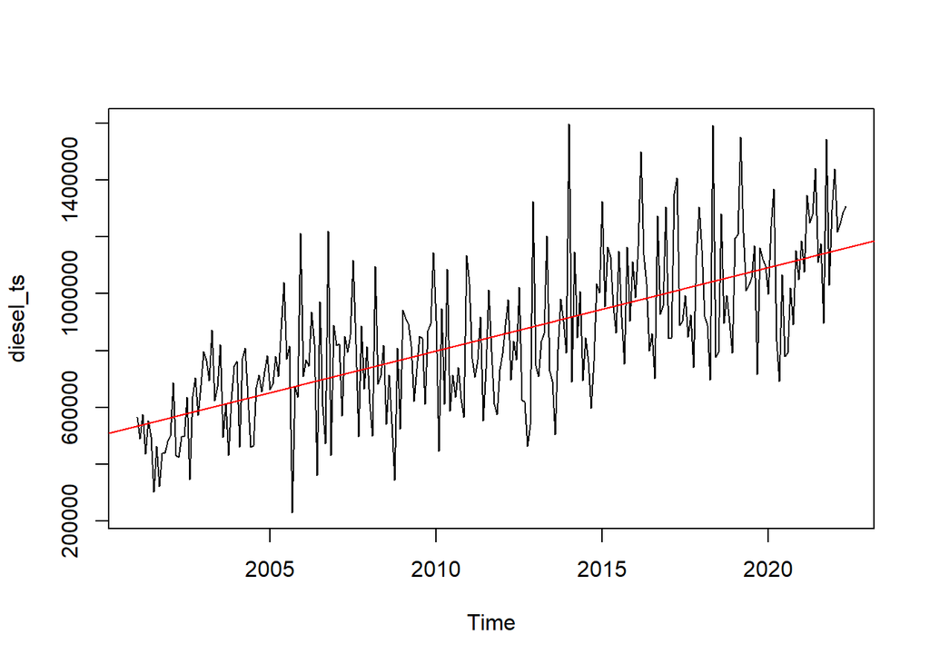

```r
#Grafica generada
plot(diesel_ts)
abline(reg=lm(diesel_ts~time(diesel_ts)), col=c("red"))
```

Como se observa anteriormente, la grafica nos demuestra el comportamiento de la importacion de la gasolina Diesel desde 2001 hasta mayo de 2022, donde se observa que ha ido en aumento conforme los años.

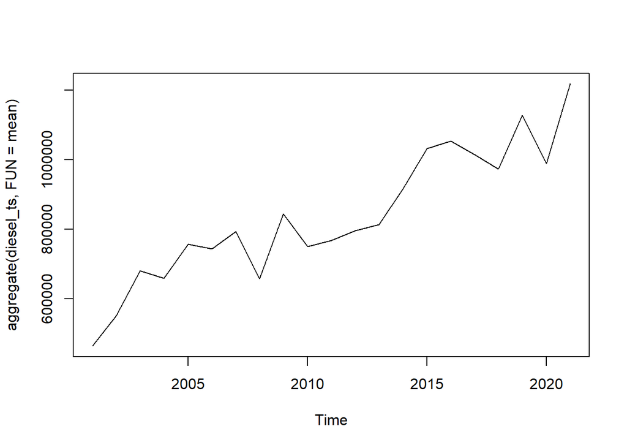

```r
plot(aggregate(diesel_ts,FUN=mean))
```

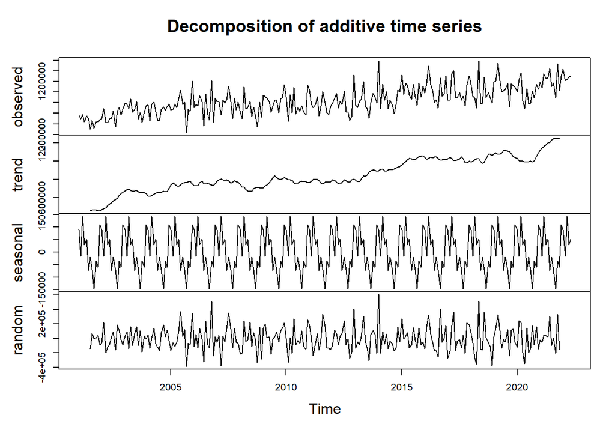

```r
dec.Diesel<-decompose(diesel_ts)
plot(dec.Diesel)
```

Podemos observar una serie con tendencia a aumentar, que no es estacionaria en varianza, y además tiene estacionalidad.

#### Estimacion

Cómo no es estacionaria en varianza le haremos una transformación logaritmica para hacerla constante en varianza. Lo haremos con la serie de entrenamiento que es la que nos ayudará a predecir

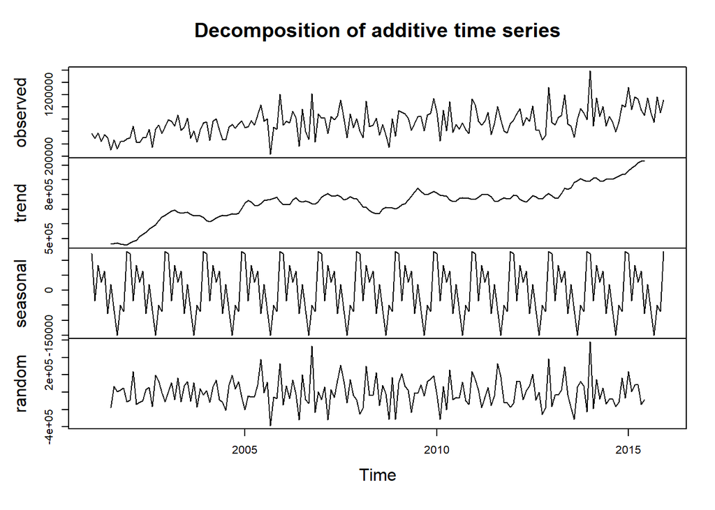

```r
train <- head(diesel_ts, round(length(diesel_ts) * 0.7))
h <- length(diesel_ts) - length(train)
test <- tail(diesel_ts, h)

#Aplicaremos una transformación logarítmica
logDiesel <- log(train)
plot(decompose(train))
```

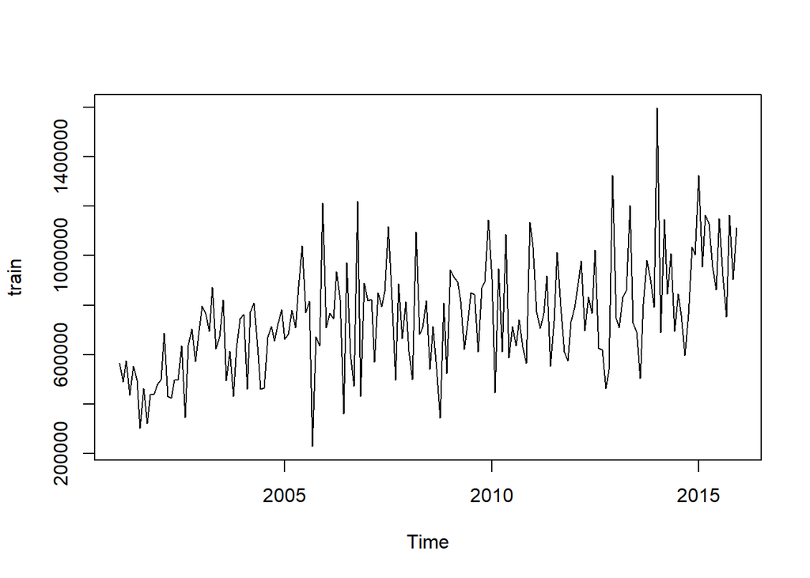

```r
#Ver el gráfico de la serie
plot(train)
```

```r
#Para saber si hay raíces unitarias
adfTest(train)
```

```
##
## Title:
##  Augmented Dickey-Fuller Test
##
## Test Results:
##   PARAMETER:
##     Lag Order: 1
##   STATISTIC:
##     Dickey-Fuller: -0.9902
##   P VALUE:
##     0.2992
##
## Description:
##  Mon Aug 08 23:40:07 2022 by user: xavih
```

```r
unitrootTest(train)
```

```
##
## Title:
##  Augmented Dickey-Fuller Test
##
## Test Results:
##   PARAMETER:
##     Lag Order: 1
##   STATISTIC:
##     DF: -0.9902
##   P VALUE:
##     t: 0.2879
##     n: 0.4732
##
## Description:
##  Mon Aug 08 23:40:07 2022 by user: xavih
```

Como se observa en varias pruebas el valor de P es mayor a 0.05 por lo que no se puede rechazar la hipotis nula de ausencia de raices. Esto significa que no es estacionaria en media. Ahora veamos con diferenciacion.

```r
adfTest(diff(train))
```

```
##
## Title:
##  Augmented Dickey-Fuller Test
##
## Test Results:
##   PARAMETER:
##     Lag Order: 1
##   STATISTIC:
##     Dickey-Fuller: -15.8452
##   P VALUE:
##     0.01
##
## Description:
##  Mon Aug 08 23:40:07 2022 by user: xavih
```

```r
unitrootTest(diff(train))
```

```
##
## Title:
##  Augmented Dickey-Fuller Test
##
## Test Results:
##   PARAMETER:
##     Lag Order: 1
##   STATISTIC:
##     DF: -15.8452
##   P VALUE:
##     t: < 2.2e-16
##     n: 0.004834
##
## Description:
##  Mon Aug 08 23:40:07 2022 by user: xavih
```

Como se puede ver el valor de p ahora sí está por debajo de 0.05 por lo que se puede descartar la hipótesis nula de que existan raices unitarias. Es necesaria solo una diferenciación. Es decir d = 1. Trataremos de identificar los parámetros p y q usando los gráficos de autocorrelación y autocorrelación parcial.

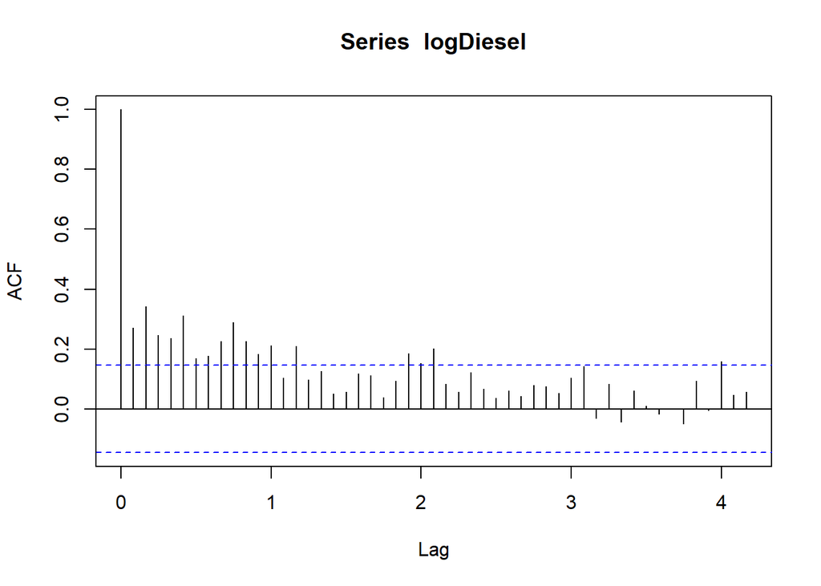

```r
#Gráfico de autocorrelación
acf(logDiesel,50)
```

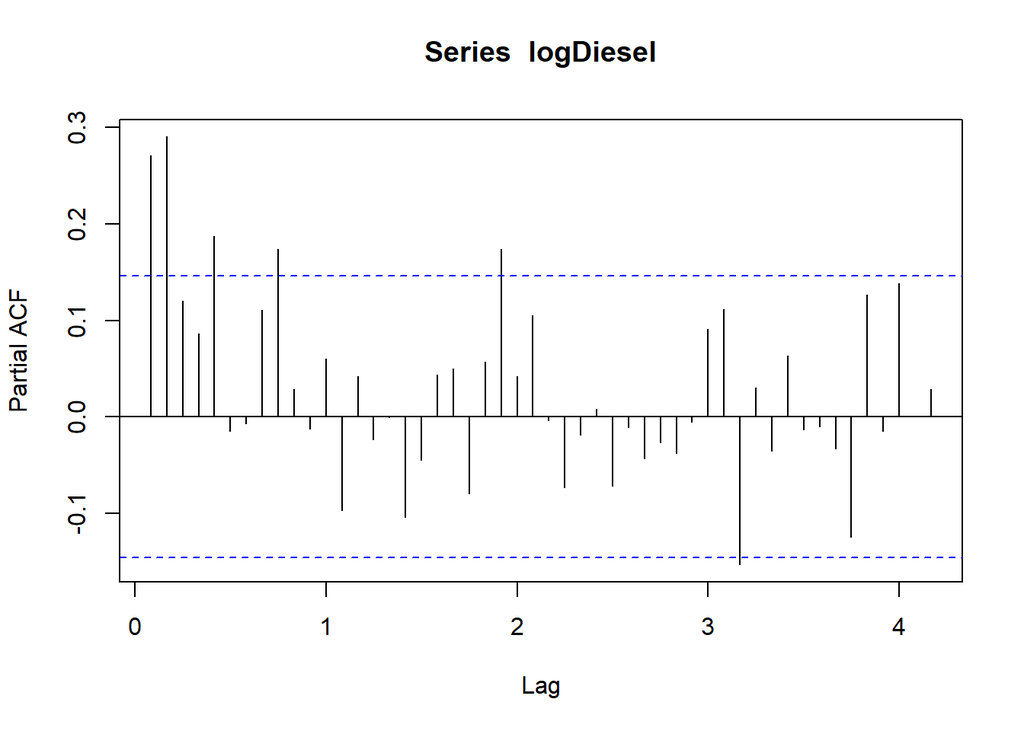

```r
pacf(logDiesel,50)
```

Veamos si hay estacionalidad en la serie. Si volvemos a ver la descomposición de la serie en su componente estacional.

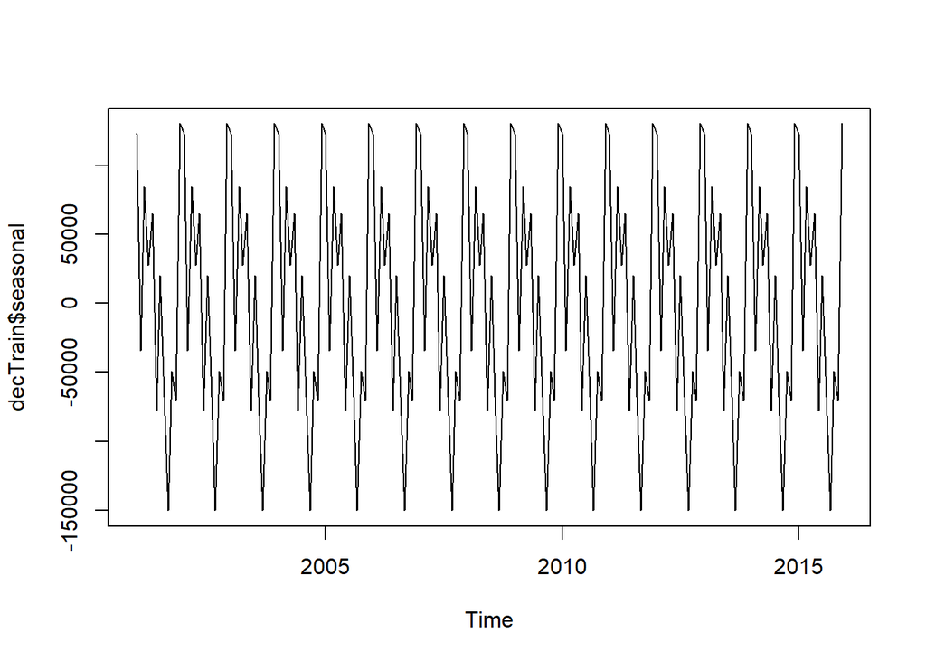

```r
decTrain <- decompose(train)
plot(decTrain$seasonal)
```

Al parecer sí existe estacionalidad en la serie. Para tener una idea de los parámetros estacionales veremos las funciones de autocorrelación y autocorrelación parcial con 36 resagos para ver en que momentos son los picos estacionales. Se usará la serie estacionarizada.

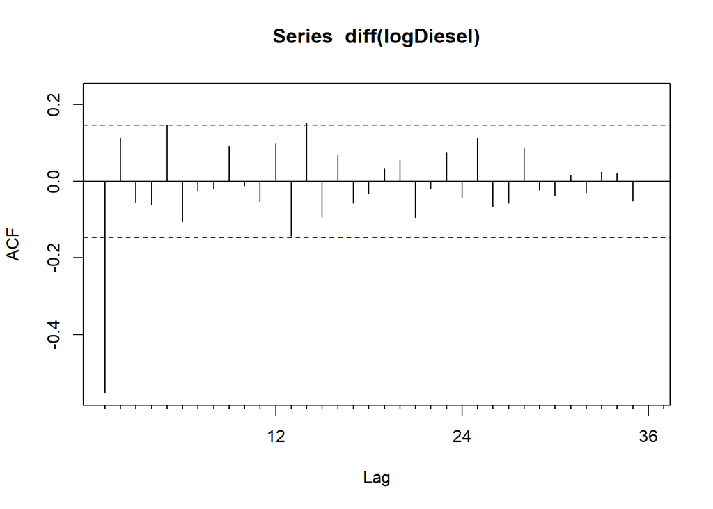

```r
Acf(diff(logDiesel),36)
```

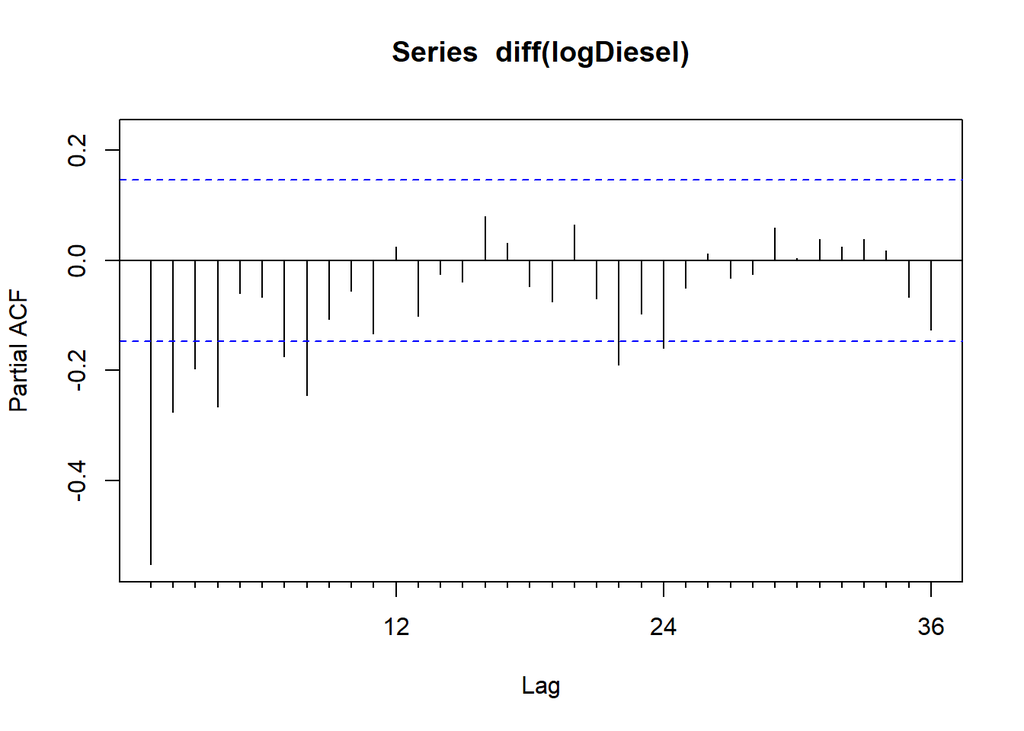

```r
Pacf(diff(logDiesel),36)
```

```r
fitArima <- arima(logDiesel,order=c(1,1,1),seasonal = c(1,1,0))
fitAutoArima <- auto.arima(train)
```

#### Significacion de los coeficientes

```r
library(lmtest)

coeftest(fitArima)
```

```
##
## z test of coefficients:
##
##       Estimate Std. Error  z value Pr(>|z|)
## ar1  -0.174782   0.082970  -2.1066  0.03516 *
## ma1  -0.931635   0.033359 -27.9272  < 2e-16 ***
## sar1 -0.554280   0.064603  -8.5797  < 2e-16 ***
## ---
## Signif. codes:  0 '***' 0.001 '**' 0.01 '*' 0.05 '.' 0.1 ' ' 1
```

Cómo se puede obserevar todos los coeficientes son significativos. Veamos ahora el modelo generado de forma automática por R

```r
coeftest(fitAutoArima)
```

```
##
## z test of coefficients:
##
##          Estimate  Std. Error  z value  Pr(>|z|)
## ar1     -0.045898    0.082830  -0.5541  0.579492
## ar2      0.071233    0.083508   0.8530  0.393658
## ar3     -0.022360    0.080996  -0.2761  0.782498
## ma1     -0.952540    0.039890 -23.8790 < 2.2e-16 ***
## drift 2595.727173  859.367144   3.0205  0.002523 **
## ---
## Signif. codes:  0 '***' 0.001 '**' 0.01 '*' 0.05 '.' 0.1 ' ' 1
```

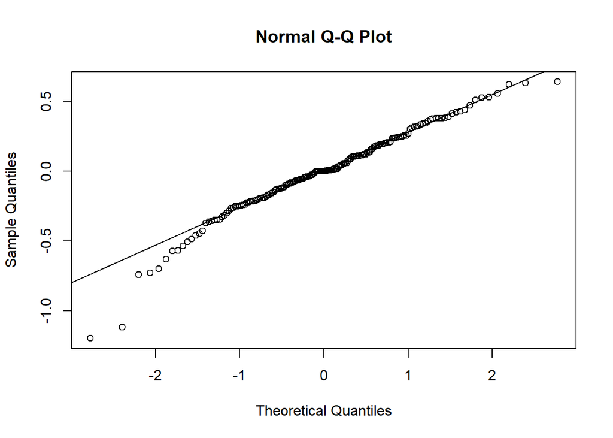

```r
qqnorm(fitArima$residuals)
qqline(fitArima$residuals)
```

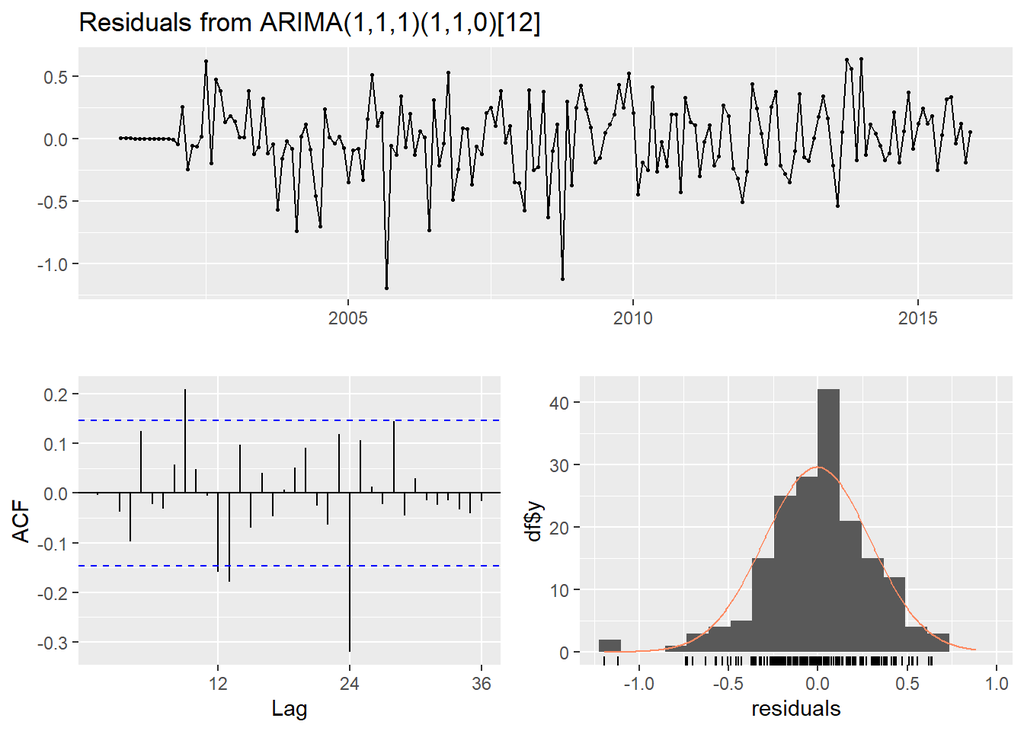

```
##
##  Ljung-Box test
##
## data:  Residuals from ARIMA(1,1,1)(1,1,0)[12]
## Q* = 57.205, df = 21, p-value = 3.351e-05
##
## Model df: 3.   Total lags used: 24
```

```r
checkresiduals(fitArima)
```

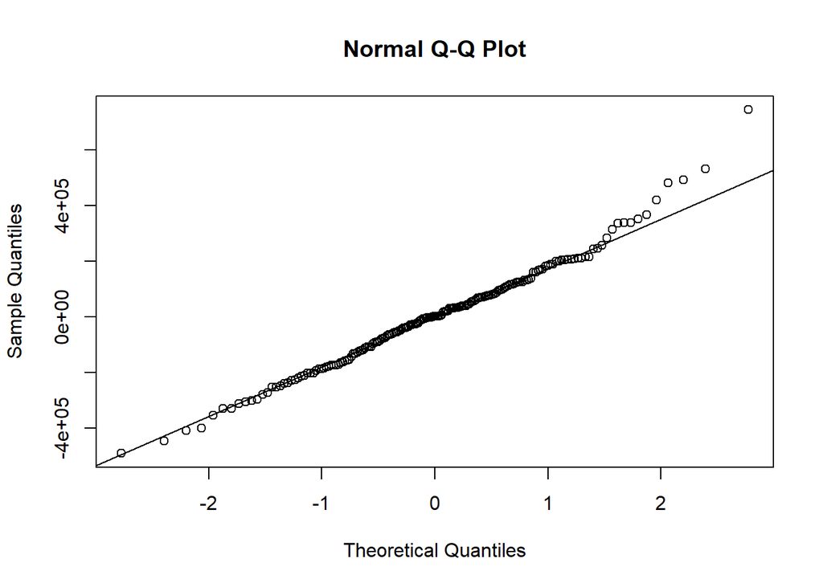

```r
qqnorm(fitAutoArima$residuals)
qqline(fitAutoArima$residuals)
```

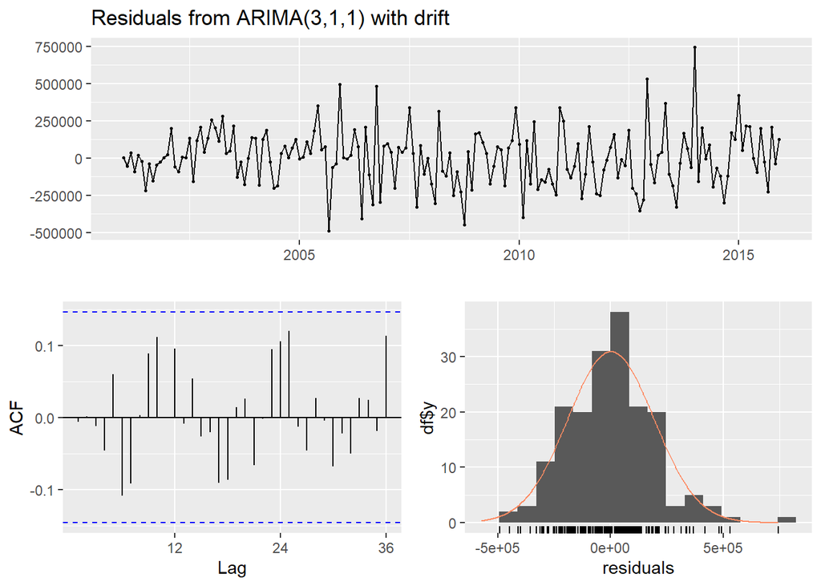

```
##
##  Ljung-Box test
##
## data:  Residuals from ARIMA(3,1,1) with drift
## Q* = 19.889, df = 20, p-value = 0.4649
##
## Model df: 4.   Total lags used: 24
```

```r
checkresiduals(fitAutoArima)
```

Como podemos observar también es un buen modelo para predecir.

#### Prediccion

```r
# Hacer el modelo

auto.arima(diesel_ts)
```

```
## Series: diesel_ts
## ARIMA(3,1,1)
##
## Coefficients:
##           ar1     ar2     ar3      ma1
##       -0.0212  0.0333  0.0049  -0.9056
## s.e.   0.0691  0.0683  0.0666   0.0301
##
## sigma^2 = 4.256e+10:  log likelihood = -3494.77
## AIC=6999.54   AICc=6999.78   BIC=7017.27
```

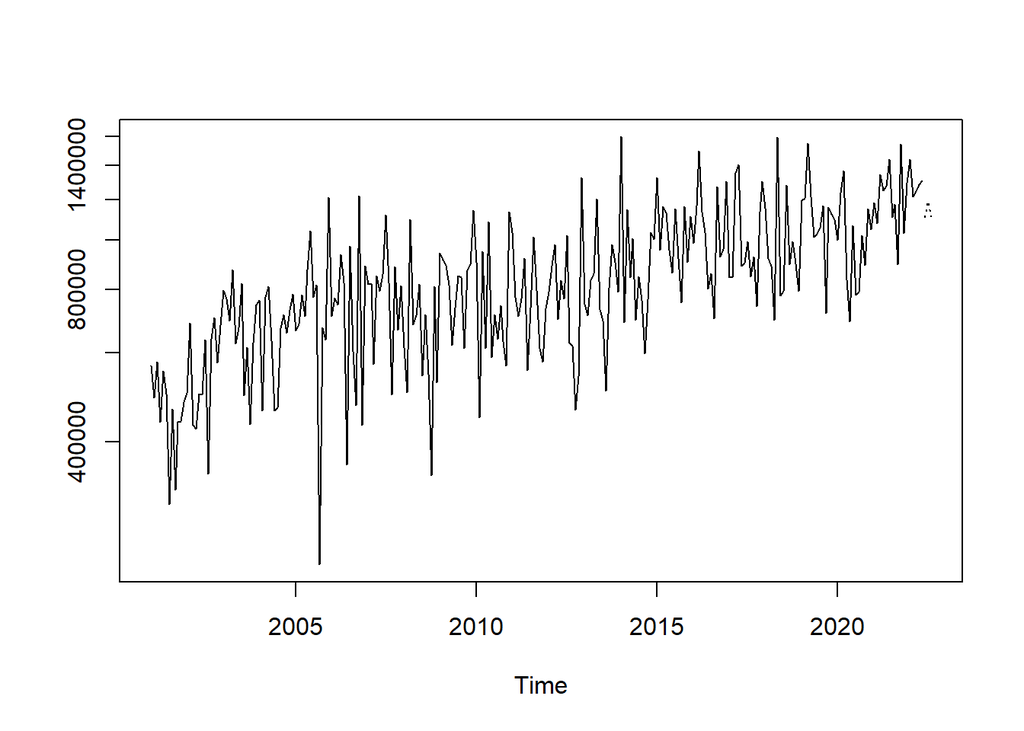

```r
fit <- arima(log(diesel_ts), c(0, 1, 1),seasonal = list(order = c(0, 1, 1), period = 12))
pred <- predict(fit, n.ahead = 3)
ts.plot(diesel_ts,2.718^pred$pred, log = "y", lty = c(1,3))
```

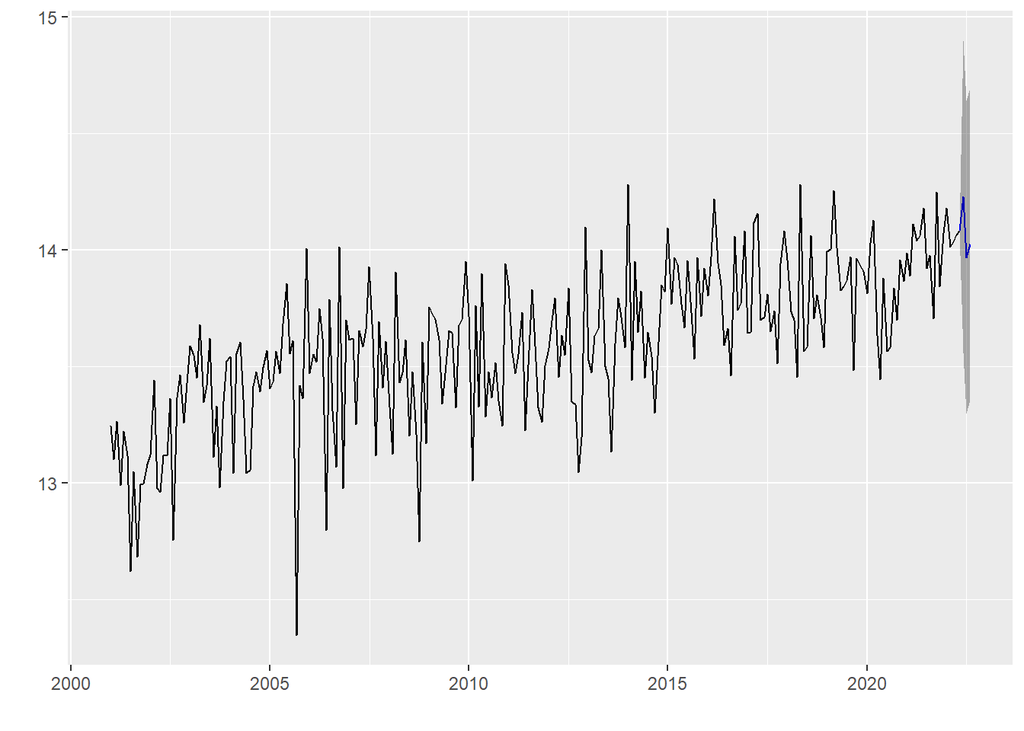

```r
fit2 <- arima(log(diesel_ts), c(2, 1, 1),seasonal = list(order = c(0, 1, 0), period = 12))

forecastAP <- forecast(fit2, level = c(95), h = 3)
autoplot(forecastAP)
```

```r
diesel_ts2018 <- ts( diesel$`Diesel alto azufre`, start = c(2001,1), end=c(2020,12) ,frequency = 12)

auto.arima(diesel_ts2018)
```

```
## Series: diesel_ts2018
## ARIMA(3,1,1)(0,0,1)[12]
##
## Coefficients:
##           ar1      ar2      ar3      ma1    sma1
##       -0.0264  -0.0127  -0.0135  -0.9149  0.0953
## s.e.   0.0699   0.0701   0.0684   0.0275  0.0628
##
## sigma^2 = 4.233e+10:  log likelihood = -3261.59
## AIC=6535.17   AICc=6535.53   BIC=6556.03
```

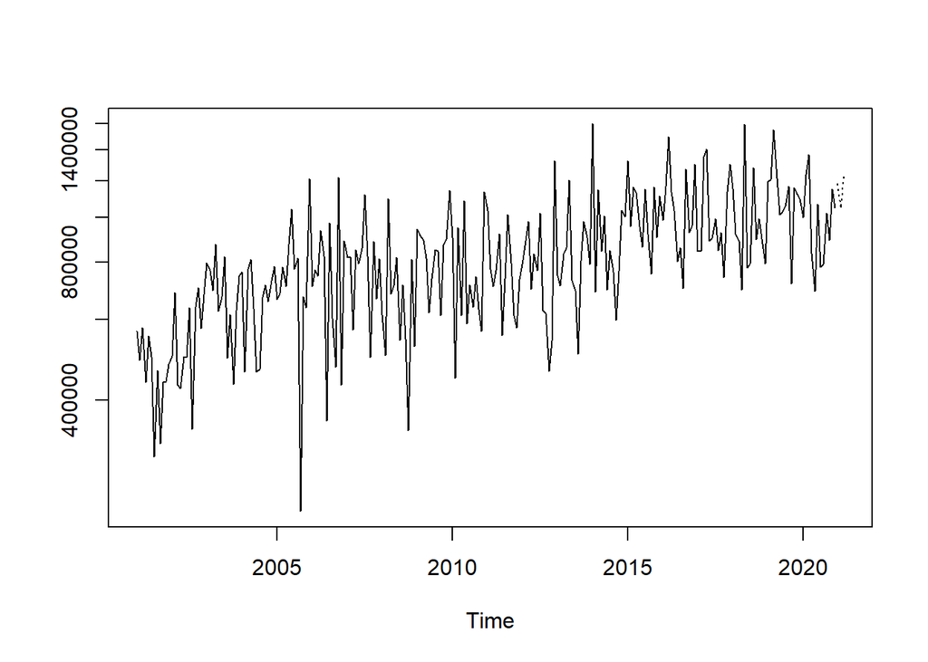

```r
fit <- arima(log(diesel_ts2018), c(0, 1, 1),seasonal = list(order = c(0, 1, 1), period = 12))
pred <- predict(fit, n.ahead = 3)
ts.plot(diesel_ts2018,2.718^pred$pred, log = "y", lty = c(1,3))
```

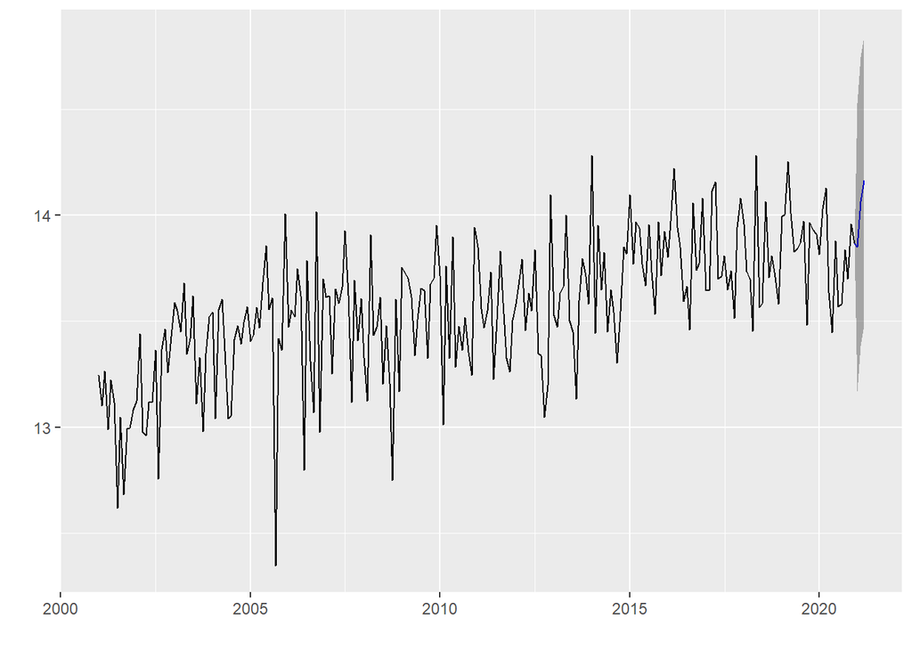

```r
fit2 <- arima(log(diesel_ts2018), c(2, 1, 1),seasonal = list(order = c(0, 1, 0), period = 12))

forecastAP <- forecast(fit2, level = c(95), h = 3)
autoplot(forecastAP)
```

Como se observa con las graficas anteriores, si se realizo una buena prediccion, ya que es muy similar a las graficas anteriormente generadas.

#### Prohet

```r
#install.packages('prophet')
library(prophet)
library(zoo)
df<-data.frame(ds=as.Date(as.yearmon(time(train))),y=as.matrix(train) )
testdf<-data.frame(ds=as.Date(as.yearmon(time(test))),y=as.matrix(test) )
head(df)
```

```
##           ds        y
## 1 2001-01-01 566102.0
## 2 2001-02-01 489525.8
## 3 2001-03-01 575559.7
## 4 2001-04-01 437745.4
## 5 2001-05-01 552609.1
## 6 2001-06-01 497855.3
```

```r
fitProphet<-prophet(df,yearly.seasonality = T,weekly.seasonality = T)
```

```
## Disabling daily seasonality. Run prophet with daily.seasonality=TRUE to override this.
```

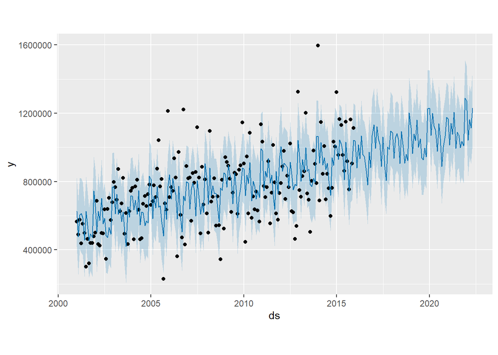

```r
future <- make_future_dataframe(fitProphet,periods = h,freq = "month", include_history = T)
p <- predict(fitProphet,future)
p<-p[,c("ds","yhat","yhat_lower","yhat_upper")]
plot(fitProphet,p)
```

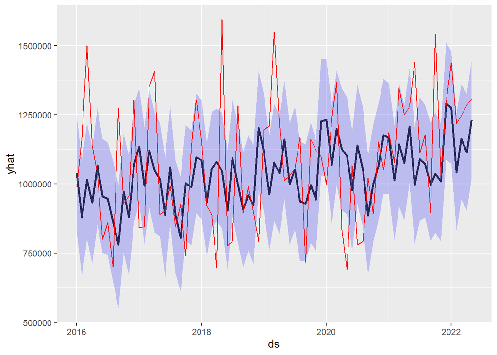

```r
pred<-tail(p,h)
pred$y<-testdf$y


ggplot(pred, aes(x=ds, y=yhat)) +
   geom_line(size=1, alpha=0.8) +
   geom_ribbon(aes(ymin=yhat_lower, ymax=yhat_upper), fill="blue", alpha=0.2) +
   geom_line(data=pred, aes(x=ds, y=y),color="red")
```

### Comportamiento durante la pandemia

Como bien sabemos, las importaciones en general de la gasolina disminuyó considerablemente en la pandemia por el Covid-19 porque la gente no salía de sus casas, por consiguiente no se hacía uso de la gasolina. Esto afectó en parte en las predicciones hechas para los tres modelos porque los datos son dependientes para poder predecir y lo comprobamos en la comparación de ambas gráficas generadas en la parte de predecir, no coincidían del todo pero la idea era la misma. Los valores habituales ya en el regreso a la “nueva normalidad” se están recuperando poco a poco, más en el caso de la gasolina regular, que al menos la tendencia a que la importación de combustible va incrementando, sin embargo hay alguno que otro dato extremo, lo que tiene sentido porque luego de la pandemia vino la guerra entre Ucrania y Rusia lo que trajo consecuencias a todo el mundo como el alza de los precios del petróleo. Entonces no se han recuperado los datos habituales del todo en los últimos años.

Y hay que mencionar el caso de la gasolina superior, la importación de este combustible incrementó notablemente luego de la pandemia, puede ser debido a que todo la gente fue volviendo a sus actiidades diarias de forma presencial y sin afectar los elevados precios de la gasolina que vinieron después debido a que la gente en su mayoría utilizan carro para movilizarse y pagan la gasolina sin importar el cambio en el precio porque al final tienen responsabilidades que cumplir. Finalmente, con el caso del diesel, su importación no tuvo grandes diferencias durante la pandemia como los otros combustibles, la cantidad importada siempre fue alta luego baja pero si se nota más esa estacionariedad en varianza se podría decir, obviamente tuvo picos bajos durante los años de la pandemia y durante la guerra entre Ucrania y Rusia pero no con mucha notoriedad como los otros combustibles, por lo que su predicción fue mejor que las demás.